# Thành viên nhóm

- Nguyễn Thanh Bình - 20133025
- Nguyễn Nhật Triều - 20133102
- Đoàn Quốc Trung - 20133104

# ĐỀ XUẤT

## 1.Giới thiệu:

- Tên đề tài: Nghiên cứu về dân số ước tính hiện tại của các nước trên thế giới .
- Nguồn tải: https://www.kaggle.com/datasets/anandhuh/countries-in-the-world-by-population-2022
- Nguồn thu thập dữ liệu: https://worldpopulationreview.com/
- Cách thu thập dữ liệu : Thực hiện khảo sát dân số ở từng quốc gia , từng khu vực.
- Ý tưởng: Vấn đề về dân số là một vấn đề gây nhức nhối cho các khu vực trên toàn thế giới nói chung cũng như các quốc gia trên toàn thế giới nói riêng. Nó gây ra nhiều vấn đề tiêu cực cho xã hội nếu không được quản lý kịp thời. Vì thế nhóm chúng tôi đã làm một bài phân tích dân số trên toàn thế giới dựa theo các số liệu đã thu thập được. Mục tiêu của bài phân tích là làm rõ các nguyên nhân có thể làm bùng nổ dân số, gia tăng tỷ lê dân số già hóa,... Thông qua đó đưa ra các kết luận so sánh nằm đánh giá chung về tình hình dân số thế giới cũng như một số biện pháp giúp ổn định tình hình dân số thế giới.

## 2.Dữ liệu:

```python
#Load data
import pandas as pd
df = pd.read_csv('world_population.csv')

df.head(20)
```

|  | Country/Other | Population (2020) | Yearly Change | Net Change | Density (P/Km²) | Land Area (Km²) | Migrants (net) | Fert. Rate | Med. Age | Urban Pop % | World Share |
| --- | --- | --- | --- | --- | --- | --- | --- | --- | --- | --- | --- |
| 0 | Afghanistan | 38928346 | 2.33 | 886592 | 60 | 652860 | -62920 | 4.6 | 18 | 25.0 | 0.50 |
| 1 | Albania | 2877797 | -0.11 | -3120 | 105 | 27400 | -14000 | 1.6 | 36 | 63.0 | 0.04 |
| 2 | Algeria | 43851044 | 1.85 | 797990 | 18 | 2381740 | -10000 | 3.1 | 29 | 73.0 | 0.56 |
| 3 | Angola | 32866272 | 3.27 | 1040977 | 26 | 1246700 | 6413 | 5.6 | 17 | 67.0 | 0.42 |
| 4 | Antigua and Barbuda | 97929 | 0.84 | 811 | 223 | 440 | 0 | 2.0 | 34 | 26.0 | 0.00 |
| 5 | Argentina | 45195774 | 0.93 | 415097 | 17 | 2736690 | 4800 | 2.3 | 32 | 93.0 | 0.58 |
| 6 | Armenia | 2963243 | 0.19 | 5512 | 104 | 28470 | -4998 | 1.8 | 35 | 63.0 | 0.04 |
| 7 | Aruba | 106766 | 0.43 | 452 | 593 | 180 | 201 | 1.9 | 41 | 44.0 | 0.00 |
| 8 | Australia | 25499884 | 1.18 | 296686 | 3 | 7682300 | 158246 | 1.8 | 38 | 86.0 | 0.33 |
| 9 | Austria | 9006398 | 0.57 | 51296 | 109 | 82409 | 65000 | 1.5 | 43 | 57.0 | 0.12 |
| 10 | Azerbaijan | 10139177 | 0.91 | 91459 | 123 | 82658 | 1200 | 2.1 | 32 | 56.0 | 0.13 |
| 11 | Bahamas | 393244 | 0.97 | 3762 | 39 | 10010 | 1000 | 1.8 | 32 | 86.0 | 0.01 |
| 12 | Bahrain | 1701575 | 3.68 | 60403 | 2239 | 760 | 47800 | 2.0 | 32 | 89.0 | 0.02 |
| 13 | Bangladesh | 164689383 | 1.01 | 1643222 | 1265 | 130170 | -369501 | 2.1 | 28 | 39.0 | 2.11 |
| 14 | Barbados | 287375 | 0.12 | 350 | 668 | 430 | -79 | 1.6 | 40 | 31.0 | 0.00 |
| 15 | Belarus | 9449323 | -0.03 | -3088 | 47 | 202910 | 8730 | 1.7 | 40 | 79.0 | 0.12 |
| 16 | Belgium | 11589623 | 0.44 | 50295 | 383 | 30280 | 48000 | 1.7 | 42 | 98.0 | 0.15 |
| 17 | Belize | 397628 | 1.86 | 7275 | 17 | 22810 | 1200 | 2.3 | 25 | 46.0 | 0.01 |
| 18 | Benin | 12123200 | 2.73 | 322049 | 108 | 112760 | -2000 | 4.9 | 19 | 48.0 | 0.16 |
| 19 | Bhutan | 771608 | 1.12 | 8516 | 20 | 38117 | 320 | 2.0 | 28 | 46.0 | 0.01 |

```python
print('Số quan sát:', len(df))
```

```
Số quan sát: 200
```

```python
print('Số chiều:', df.shape)
```

```
Số chiều: (200, 11)
```

```python
df.info()
```

```
<class 'pandas.core.frame.DataFrame'>
RangeIndex: 200 entries, 0 to 199
Data columns (total 11 columns):
Country/Other        200 non-null object
Population (2020)    200 non-null int64
Yearly Change        200 non-null float64
Net Change           200 non-null int64
Density (P/Km²)      200 non-null int64
Land Area (Km²)      200 non-null int64
Migrants (net)       200 non-null int64
Fert. Rate           200 non-null float64
Med. Age             200 non-null int64
Urban Pop %          193 non-null float64
World Share          200 non-null float64
dtypes: float64(4), int64(6), object(1)
memory usage: 17.3+ KB
```

# 3.Kế hoạch phân tích dữ liệu

- Theo kế hoạch phân tích của nhóm thì sẽ lấy ngẫu nhiên một số nước rồi xếp chúng vào các khu vực trực thuộc. Từ đó sẽ thêm 1 cột Area vào dữ liệu . Biến này đóng vai trò như là biến phân loại.

=> Từ đó nêu ra các giả thuyết so sánh các đặc tính dân số đối với các biến này khác nhau

## Phân tích dữ liệu sơ bộ

```python
df.describe()
```

|  | Population (2020) | Yearly Change | Net Change | Density (P/Km²) | Land Area (Km²) | Migrants (net) | Fert. Rate | Med. Age | Urban Pop % | World Share |
| --- | --- | --- | --- | --- | --- | --- | --- | --- | --- | --- |
| count | 2.000000e+02 | 200.000000 | 2.000000e+02 | 200.00000 | 2.000000e+02 | 200.000000 | 200.000000 | 200.000000 | 193.000000 | 200.000000 |
| mean | 3.896963e+07 | 1.201650 | 4.066385e+05 | 358.94500 | 6.483148e+05 | -12.225000 | 2.698000 | 30.560000 | 59.787565 | 0.499950 |
| std | 1.457636e+08 | 1.094145 | 1.213310e+06 | 1714.16284 | 1.813369e+06 | 123601.410843 | 1.264592 | 9.100025 | 22.181107 | 1.870026 |
| min | 9.792900e+04 | -2.470000 | -3.838400e+05 | 2.00000 | 3.000000e+01 | -653249.000000 | 1.100000 | 15.000000 | 13.000000 | 0.000000 |
| 25% | 1.947550e+06 | 0.417500 | 4.171250e+03 | 33.50000 | 2.251750e+04 | -10176.000000 | 1.775000 | 22.000000 | 43.000000 | 0.027500 |
| 50% | 8.655078e+06 | 1.085000 | 6.061500e+04 | 88.00000 | 1.102250e+05 | -980.000000 | 2.300000 | 30.000000 | 60.000000 | 0.110000 |
| 75% | 2.787725e+07 | 1.970000 | 3.605402e+05 | 226.50000 | 5.018225e+05 | 9805.750000 | 3.600000 | 39.000000 | 79.000000 | 0.360000 |
| max | 1.439324e+09 | 3.840000 | 1.358663e+07 | 21645.00000 | 1.637687e+07 | 954806.000000 | 7.000000 | 48.000000 | 100.000000 | 18.470000 |

```python
# The country with the largest population
Max=max(df['Population (2020)'])
df[df['Population (2020)']==Max]['Country/Other']
```

```
35    China
Name: Country/Other, dtype: object
```

```python
#The country with the smallest population
Min=min(df['Population (2020)'])
df[df['Population (2020)']==Min]['Country/Other']
```

```
4    Antigua and Barbuda
Name: Country/Other, dtype: object
```

[figure not shown]

```python
# Countries with Highest Population Vis
import matplotlib.pyplot as plt
info = pd.DataFrame(df['Population (2020)'].sort_values(ascending=False))
info['Country/Other'] = df['Country/Other']
data = list(map(str,(info['Country/Other'])))
x = list(data[:10])
y = list(info['Population (2020)'][:10])
plt.bar(x, y, width= 0.9, align='center',color='red', edgecolor = 'cyan')
plt.title('Countries with Lowest Population', fontdict = {'fontname':'Comic Sans MS', 'fontsize' :15})
plt.ylabel('Population', size=10)
plt.xticks(rotation=90)
plt.grid(axis='y')

plt.show()
```

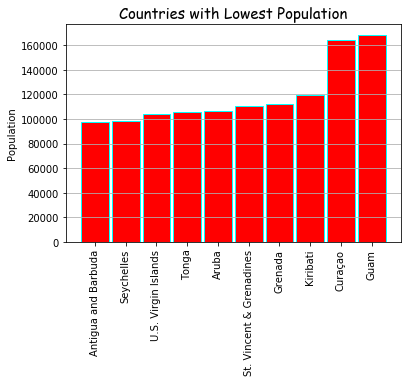

```python
# Countries with Lowest Population Vis
import matplotlib.pyplot as plt
info = pd.DataFrame(df['Population (2020)'].sort_values(ascending=True))
info['Country/Other'] = df['Country/Other']
data = list(map(str,(info['Country/Other'])))
x = list(data[:10])
y = list(info['Population (2020)'][:10])
plt.bar(x, y, width= 0.9, align='center',color='red', edgecolor = 'cyan')
plt.title('Countries with Lowest Population', fontdict = {'fontname':'Comic Sans MS', 'fontsize' :15})
plt.ylabel('Population', size=10)
plt.xticks(rotation=90)
plt.grid(axis='y')

plt.show()
```

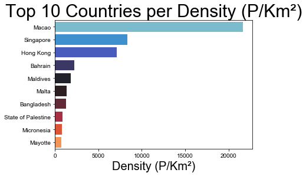

```python
# Top 10 Countries per Density (P/Km²)
import seaborn as sns
info = pd.DataFrame(df['Density (P/Km²)'].sort_values(ascending=False))
info['Country/Other'] = df['Country/Other']
data = list(map(str,(info['Country/Other'])))
x = list(data[:10])
y = list(info['Density (P/Km²)'][:10])

ax = sns.barplot(x=y,y=x, saturation = 1, palette = 'icefire')

sns.set(rc={'figure.figsize':(20,10)})
ax.set_title('Top 10 Countries per Density (P/Km²)', fontsize = 30)
ax.set_xlabel('Density (P/Km²)',fontsize = 20)
sns.set_style('darkgrid')
```

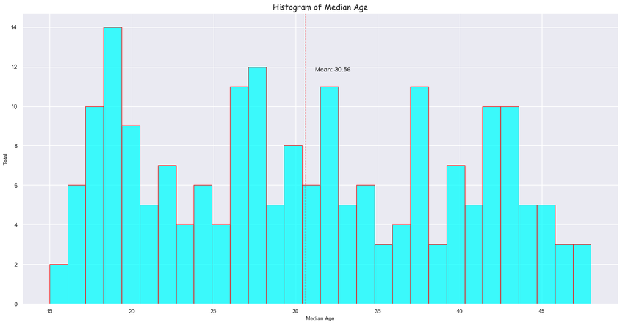

```python
# Median Age of Country/Other (Histogram Plot)
plt.hist(df['Med. Age'], bins=30,color='cyan', edgecolor = 'red',alpha=0.75)
plt.axvline(df['Med. Age'].mean(), color='red', linestyle='dashed', linewidth=1)
plt.xlabel('Median Age', size=10)
plt.ylabel('Total', size=10)
plt.title('Histogram of Median Age', fontdict = {'fontname':'Comic Sans MS', 'fontsize' :15})
min_ylim, max_ylim = plt.ylim()
plt.text(df['Med. Age'].mean()*1.02, max_ylim*0.8, 'Mean: {:.2f}'.format(df['Med. Age'].mean()))

plt.show()
```

### Các phương pháp thống kê được sử dụng:

- Kiểm định ý nghĩa thống kê dùng T-test
- Ước lượng khoảng cho giá trị trung bình

### Các giả thiết của nhóm

H0 : Mật độ dân số khu vực Châu Âu lớn hơn Châu Phi

H1 : Số người di cư đến khu vực Bắc Mỹ lớn hơn Nam Mỹ

H2 : Tỉ lệ sinh sản Châu Á nhỏ hơn Châu Âu

### Các kết quả từ phương pháp thống kê cần thiết để hỗ trợ cho giả thuyết của nhóm

- Khoảng tin cậy cho giá trị trung bình
- p-value